# Problem Set 1: Data Visualization in R (Vladyslav Fedorchenko)

# Loading dataset

One of the datasets that are available is **PRAMS** dataset that will be used to complete the task

```r
# Load the dataset
prams_data <- read_csv(here("data", "real", "prams_2011_selected.csv"))
# Show the first few rows of the dataset
head(prams_data)
```

```
## # A tibble: 6 × 8
##   location_abbr location subgroup_cat            subgroup depression_within_3_…¹
##   <chr>         <chr>    <chr>                   <chr>                     <dbl>
## 1 AR            Arkansas Adequacy of Prenatal c… ADEQUAT…                     NA
## 2 AR            Arkansas Adequacy of Prenatal c… INADEQU…                     NA
## 3 AR            Arkansas Adequacy of Prenatal c… INTERME…                     NA
## 4 AR            Arkansas Adequacy of Prenatal c… UNKNOWN…                     NA
## 5 AR            Arkansas Birth Weight            LBW (<=…                     NA
## 6 AR            Arkansas Birth Weight            NBW (>2…                     NA
## # ℹ abbreviated name: ¹depression_within_3_months_birth
## # ℹ 3 more variables: anxiety_within_3_months_birth <dbl>,
## #   binge_drinking_within_3_months_birth <dbl>,
## #   alcohol_use_within_3_months_birth <dbl>
```

# Data Check

Now we will visually inspect the dataset to understand its structure and content. This will help us identify the main variables and any potential issues with the data.

Run some code to check the structure of the dataset and the number of rows and columns

```r
# Check the structure of the dataset
str(prams_data)
```

```
## spc_tbl_ [1,222 × 8] (S3: spec_tbl_df/tbl_df/tbl/data.frame)
##  $ location_abbr                       : chr [1:1222] "AR" "AR" "AR" "AR" ...
##  $ location                            : chr [1:1222] "Arkansas" "Arkansas" "Arkansas" "Arkansas" ...
##  $ subgroup_cat                        : chr [1:1222] "Adequacy of Prenatal care" "Adequacy of Prenatal care" "Adequacy of Prenatal care" "Adequacy of Prenatal care" ...
##  $ subgroup                            : chr [1:1222] "ADEQUATE PNC" "INADEQUATE PNC" "INTERMEDIATE PNC" "UNKNOWN PNC" ...
##  $ depression_within_3_months_birth    : num [1:1222] NA NA NA NA NA NA NA NA NA NA ...
##  $ anxiety_within_3_months_birth       : num [1:1222] NA NA NA NA NA NA NA NA NA NA ...
##  $ binge_drinking_within_3_months_birth: num [1:1222] 24.6 12.6 22.2 36 21.5 24.1 25.6 21.3 24.7 22.9 ...
##  $ alcohol_use_within_3_months_birth   : num [1:1222] 53.5 28.7 40.9 54.1 45.8 49.9 48.9 47.8 60.5 43.6 ...
##  - attr(*, "spec")=
##   .. cols(
##   ..   location_abbr = col_character(),
##   ..   location = col_character(),
##   ..   subgroup_cat = col_character(),
##   ..   subgroup = col_character(),
##   ..   depression_within_3_months_birth = col_double(),
##   ..   anxiety_within_3_months_birth = col_double(),
##   ..   binge_drinking_within_3_months_birth = col_double(),
##   ..   alcohol_use_within_3_months_birth = col_double()
##   .. )
##  - attr(*, "problems")=<externalptr>
```

```r
# Summary of the dataset
summary(prams_data)
```

```
##  location_abbr        location         subgroup_cat         subgroup
##  Length:1222        Length:1222        Length:1222        Length:1222
##  Class :character   Class :character   Class :character   Class :character
##  Mode  :character   Mode  :character   Mode  :character   Mode  :character
##
##
##
##
##  depression_within_3_months_birth anxiety_within_3_months_birth
##  Min.   : 1.70                    Min.   : 1.00
##  1st Qu.: 8.90                    1st Qu.: 9.85
##  Median :12.10                    Median :12.60
##  Mean   :12.85                    Mean   :13.49
##  3rd Qu.:15.80                    3rd Qu.:16.65
##  Max.   :42.50                    Max.   :36.90
##  NA's   :775                      NA's   :775
##  binge_drinking_within_3_months_birth alcohol_use_within_3_months_birth
##  Min.   : 2.80                        Min.   : 4.90
##  1st Qu.:17.40                        1st Qu.:42.77
##  Median :22.90                        Median :53.80
##  Mean   :23.32                        Mean   :52.14
##  3rd Qu.:28.50                        3rd Qu.:62.80
##  Max.   :61.00                        Max.   :86.80
##  NA's   :62                           NA's   :62
```

```r
# Use skimr to get a more detailed summary of the dataset
skimr::skim(prams_data)
```

Data summary

| Name | prams_data |
| --- | --- |
| Number of rows | 1222 |
| Number of columns | 8 |
| _______________________ |  |
| Column type frequency: |  |
| character | 4 |
| numeric | 4 |
| ________________________ |  |
| Group variables | None |

**Variable type: character**

| skim_variable | n_missing | complete_rate | min | max | empty | n_unique | whitespace |
| --- | --- | --- | --- | --- | --- | --- | --- |
| location_abbr | 0 | 1 | 2 | 2 | 0 | 26 | 0 |
| location | 0 | 1 | 4 | 24 | 0 | 26 | 0 |
| subgroup_cat | 0 | 1 | 4 | 42 | 0 | 18 | 0 |
| subgroup | 0 | 1 | 1 | 19 | 0 | 43 | 0 |

**Variable type: numeric**

| skim_variable | n_missing | complete_rate | mean | sd | p0 | p25 | p50 | p75 | p100 | hist |
| --- | --- | --- | --- | --- | --- | --- | --- | --- | --- | --- |
| depression_within_3_months_birth | 775 | 0.37 | 12.85 | 5.95 | 1.7 | 8.90 | 12.1 | 15.80 | 42.5 | ▅▇▂▁▁ |
| anxiety_within_3_months_birth | 775 | 0.37 | 13.49 | 5.83 | 1.0 | 9.85 | 12.6 | 16.65 | 36.9 | ▂▇▅▁▁ |
| binge_drinking_within_3_months_birth | 62 | 0.95 | 23.32 | 8.38 | 2.8 | 17.40 | 22.9 | 28.50 | 61.0 | ▂▇▅▁▁ |
| alcohol_use_within_3_months_birth | 62 | 0.95 | 52.14 | 14.50 | 4.9 | 42.77 | 53.8 | 62.80 | 86.8 | ▁▃▆▇▂ |

# Task 1: Dataset Orientation

Now we need to answer the following questions:

- what one row represents
- the main variables you will use
- one limitation or caution about the dataset

## What one row represents

One row represents the percentage of the given variable (depression, anxiety, binge drinking, alcohol use) per location per subgroup.

## The main variables you will use

```r
# Check all the column names in the dataset
colnames(prams_data)
```

```
## [1] "location_abbr"
## [2] "location"
## [3] "subgroup_cat"
## [4] "subgroup"
## [5] "depression_within_3_months_birth"
## [6] "anxiety_within_3_months_birth"
## [7] "binge_drinking_within_3_months_birth"
## [8] "alcohol_use_within_3_months_birth"
```

The main variables that I will use are: - “depression_within_3_months_birth”  
- “anxiety_within_3_months_birth”  
- “binge_drinking_within_3_months_birth” - “alcohol_use_within_3_months_birth”

## One limitation or caution about the dataset

The dataset is in the long format with all the subgroups mixed in one column (subgroup_cat) - to work with it we might need to transform it to the wide format (using subgroup_cat and subroup columnns).

```r
# Check all the categories and subgroups in the dataset
unique(prams_data$subgroup_cat)
```

```
##  [1] "Adequacy of Prenatal care"
##  [2] "Birth Weight"
##  [3] "Income (years 2004 and beyond)"
##  [4] "Marital Status"
##  [5] "Maternal Age (3 Levels)"
##  [6] "Maternal Age (4 Levels)"
##  [7] "Maternal Age - 18 to 44 years in groupings"
##  [8] "Maternal Age - 18 to 44 years only"
##  [9] "Maternal Education"
## [10] "Maternal Race/Ethnicity"
## [11] "Medicaid Recipient"
## [12] "Mother Hispanic"
## [13] "None"
## [14] "Number of Previous Live Births"
## [15] "On WIC during Pregnancy"
## [16] "Pregnancy Intendedness"
## [17] "Smoked 3 months before Pregnancy"
## [18] "Smoked last 3 months of Pregnancy"
```

```r
unique(prams_data$subgroup)
```

```
##  [1] "ADEQUATE PNC"        "INADEQUATE PNC"      "INTERMEDIATE PNC"
##  [4] "UNKNOWN PNC"         "LBW (<=2500g)"       "NBW (>2500g)"
##  [7] "$10,000 to $24,999"  "$25,000 to $49,999"  "$50,000 or more"
## [10] "Less than $10,000"   "MARRIED"             "OTHER"
## [13] "20-29 yrs"           "30+ yrs"             "<20 yrs"
## [16] "20-24 yrs"           "25-34 yrs"           "35+ yrs"
## [19] "Age 18 - 24"         "Age 25 - 29"         "Age 30 - 44"
## [22] "Age 45+"             "Age < 18"            "Age 18 - 44"
## [25] "12 yrs"              "< 12 yrs"            ">12 yrs"
## [28] "Black, non-Hispanic" "Hispanic"            "Other non-Hispanic"
## [31] "White, non-Hispanic" "Medicaid"            "Non-Medicaid"
## [34] "Non-Hispanic"        "None"                "0"
## [37] "1 or more"           "Non-WIC"             "WIC"
## [40] "Intended"            "Unintended"          "Non-Smoker"
## [43] "Smoker"
```

Also, even after visual inspection I see that some variables has a lot of NA values.

```r
# Show the number of NA values in each column
sapply(prams_data, function(x) sum(is.na(x)))
```

```
##                        location_abbr                             location
##                                    0                                    0
##                         subgroup_cat                             subgroup
##                                    0                                    0
##     depression_within_3_months_birth        anxiety_within_3_months_birth
##                                  775                                  775
## binge_drinking_within_3_months_birth    alcohol_use_within_3_months_birth
##                                   62                                   62
```

# Task 2: Counts, Composition, Or Rank

Create one plot that answers a categorical question.

Examples:

- Which race/ethnicity categories make up the largest population share in selected states?
- How do states rank by total population?
- Which PRAMS subgroup categories appear most often?

Your plot should use clear labels and a short interpretation.

We will try to answer the question: **“Which PRAMS subgroup categories appear most often?”**

We will **summarize data** here to match the task requirement, so we will count the occurrences of each PRAMS subgroup category and then build a horizontal bar chart to visualize the counts of each subgroup category.

```r
# Count the occurrences of each PRAMS subgroup category - data summarisation
subgroup_counts <- prams_data %>%
    group_by(subgroup_cat) %>%
    summarise(count = n()) %>%
    arrange(desc(count))

subgroup_counts
```

```
## # A tibble: 18 × 2
##    subgroup_cat                               count
##    <chr>                                      <int>
##  1 Maternal Age - 18 to 44 years in groupings   130
##  2 Adequacy of Prenatal care                    104
##  3 Income (years 2004 and beyond)               104
##  4 Maternal Age (4 Levels)                      104
##  5 Maternal Race/Ethnicity                      104
##  6 Maternal Age (3 Levels)                       78
##  7 Maternal Education                            78
##  8 Birth Weight                                  52
##  9 Marital Status                                52
## 10 Medicaid Recipient                            52
## 11 Mother Hispanic                               52
## 12 Number of Previous Live Births                52
## 13 On WIC during Pregnancy                       52
## 14 Pregnancy Intendedness                        52
## 15 Smoked 3 months before Pregnancy              52
## 16 Smoked last 3 months of Pregnancy             52
## 17 Maternal Age - 18 to 44 years only            26
## 18 None                                          26
```

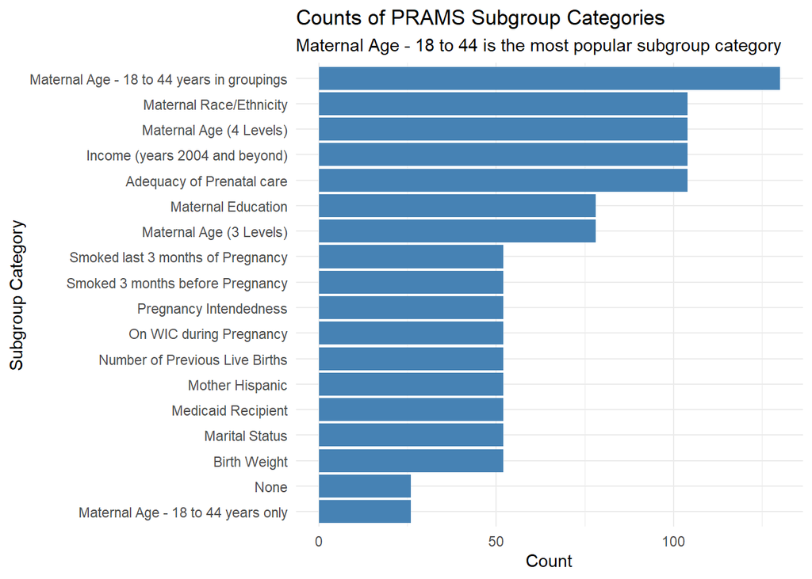

```r
# Now can build hbar chart to visualize the counts of each subgroup category
cat_plot <- ggplot(subgroup_counts, aes(x = count, y = reorder(subgroup_cat, count))) +
    geom_bar(stat = "identity", fill = "steelblue") +
    labs(title = "Counts of PRAMS Subgroup Categories",
        subtitle = "Maternal Age - 18 to 44 is the most popular subgroup category",
         x = "Count",
         y = "Subgroup Category") +
    theme_minimal()

print(cat_plot)
```

# Task 3: Distribution Or Grouped Summary

Create one plot that examines center, spread, shape, outliers, or grouped differences.

Examples:

-What is the distribution of PRAMS binge drinking estimates across state/subgroup rows? -How do PRAMS estimates differ by subgroup category? -How do race/ethnicity population shares vary across states?

Your plot should include a written interpretation that mentions what the plotted values represent.

We will answer the question: **“How alcohol use within 3 months birth differs by income level?”**

```r
# Filter only "Income (years 2004 and beyond)"
income_data <- prams_data %>%
    filter(subgroup_cat == "Income (years 2004 and beyond)")

# Show total number of rows in the filtered dataset
nrow(income_data)
```

```
## [1] 104
```

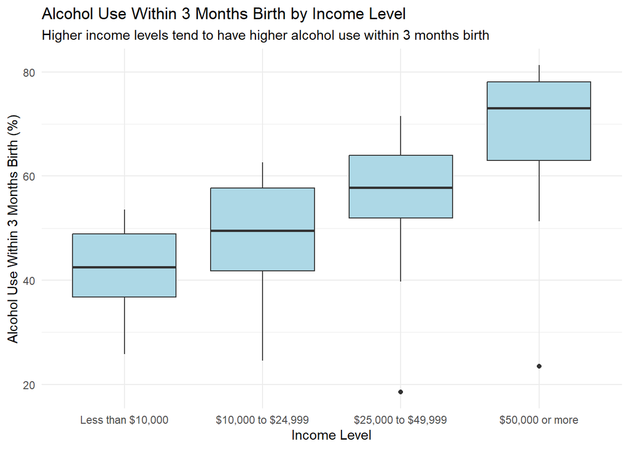

```r
# Set factor to show plot in the order of income levels
income_data$subgroup <- factor(income_data$subgroup,
                            levels = c("Less than $10,000", "$10,000 to $24,999", "$25,000 to $49,999", "$50,000 or more"))

# Now build boxplot to visualize the distribution of alcohol use within 3 months birth for each income level
income_plot <- ggplot(income_data, aes(x = subgroup, y = alcohol_use_within_3_months_birth)) +
    geom_boxplot(fill = "lightblue") +
    labs(title = "Alcohol Use Within 3 Months Birth by Income Level",
            subtitle = "Higher income levels tend to have higher alcohol use within 3 months birth",
         x = "Income Level",
         y = "Alcohol Use Within 3 Months Birth (%)") +
    theme_minimal()

print(income_plot)
```

# Task 4: Association Or Comparison Across Groups

reate one plot that compares two variables or compares a pattern across groups.

Examples:

- How are PRAMS alcohol use and binge drinking estimates related?
- How do state population rank and one race/ethnicity population share relate?
- How does a pattern differ across a small number of selected groups?

Your plot should avoid overclaiming. If the data are pre-aggregated, say so.

We will answer the question: **“How are PRAMS alcohol use and binge drinking estimates related?”** and build scatter plot for that one.

But we probably need to pre-aggregate the data to get the average alcohol use and binge drinking estimates for each subgroup category.

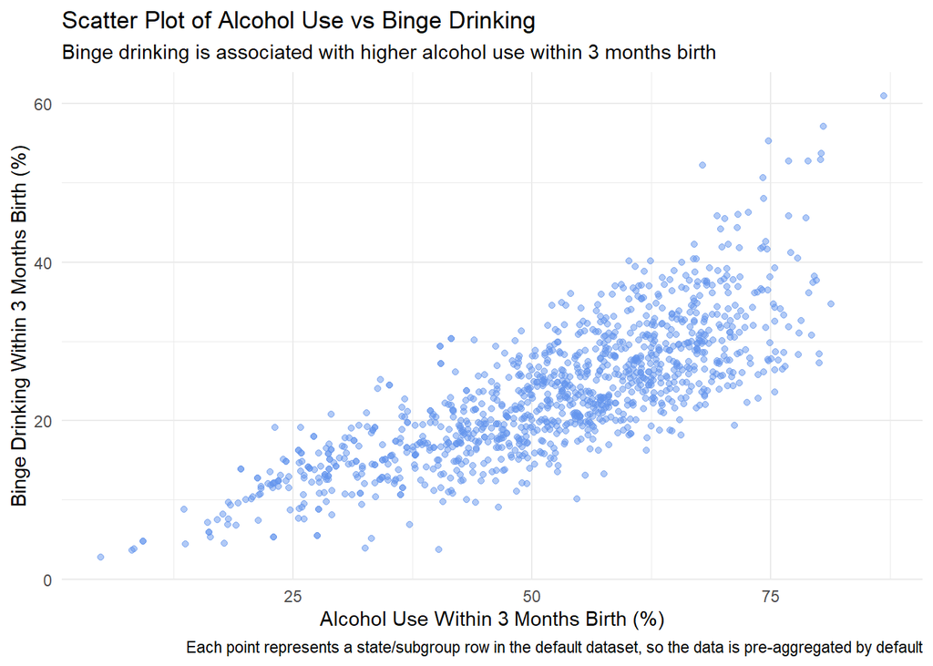

```r
# Create scatter plot without an aggregation to check
scatter_plot <- ggplot(prams_data, aes(x = alcohol_use_within_3_months_birth, y = binge_drinking_within_3_months_birth)) +
    geom_point(color = "cornflowerblue", alpha = 0.5) +
    labs(title = "Scatter Plot of Alcohol Use vs Binge Drinking",
    subtitle = "Binge drinking is associated with higher alcohol use within 3 months birth",
    caption = "Each point represents a state/subgroup row in the default dataset, so the data is pre-aggregated by default",
         x = "Alcohol Use Within 3 Months Birth (%)",
         y = "Binge Drinking Within 3 Months Birth (%)") +
    theme_minimal()

print(scatter_plot)
```

# Task 5: Reflection

Write a short paragraph answering:

- Which visualization was most useful for exploratory analysis?
- What did it help you notice?
- What question would you ask next?

## Which visualization was most useful for exploratory analysis?

The most useful visualization for exploratory analysis was the boxplot that examined the distribution of alcohol use within 3 months birth by income level.

## What did it help you notice?

This plot helped me notice that higher income levels tend to have higher alcohol use within 3 months birth, which is an interesting pattern that I would not have noticed just by looking at the summary statistics.

## What question would you ask next?

I would like to check that other categories are associated with higher alcohol use within 3 months birth as well. For example, I would like to check if there is a similar pattern for education level or age group. Also I would have checked the relationship between alcohol use and binge drinking more deeply, maybe by looking at the correlation coefficient or by building a regression model to see if alcohol use can predict binge drinking, so maybe income level is a confounding variable in that relationship.